# WSP MvF Analyses

# Aggregate Pathway Enrichment Figures

Import data files.

```r
# Read in files
canon_down <- read_excel("C:/Users/mnale/OneDrive - University of North Carolina at Chapel Hill/WSP Proteomics Project/data/UPDATED Pre vs Post canonical pathways IPA.xls", sheet = "R_data_down")
canon_up <- read_excel("C:/Users/mnale/OneDrive - University of North Carolina at Chapel Hill/WSP Proteomics Project/data/UPDATED Pre vs Post canonical pathways IPA.xls", sheet = "R_data_up")
cell_funct <- read_excel("C:/Users/mnale/OneDrive - University of North Carolina at Chapel Hill/WSP Proteomics Project/data/UPDATED Pre vs Post diseases and functions.xls", sheet = "R_data")
M.F <- read_excel("C:/Users/mnale/OneDrive - University of North Carolina at Chapel Hill/WSP Proteomics Project/data/IPA MvF Pathways.xlsx", sheet = "R_data")
```

## Bar graphs

Bar graphs of top down and up regulated IPA canonical pathways from Pre vs Post comparison. I cut this” colour = c(“black”, “black”, “slateblue”, “slateblue”, “aquamarine4”, “aquamarine4”, “slateblue”, “slateblue”, “aquamarine4”, “black”),” from the text.color

[figure not shown]

```r
# I will represent this graph using log2 p-values, therefore I will multiply the Neg_Log_P.value by -1.
canon_down$Log_P.value <- -1 * canon_down$Neg_Log_P.value

# Selecting for the top 10 most downregulated pathways.
Top_Ten_Down <- canon_down %>%
  filter(Log_P.value < 0) %>%
  slice_head(n = 10)

# Adjusting the pathways names to fit on plot.
Top_Ten_Down$Ingenuity_Canonical_Pathways[Top_Ten_Down$Ingenuity_Canonical_Pathways == "Fcγ Receptor-mediated Phagocytosis in Macrophages and Monocytes"] <-
  "Fcγ Receptor-mediated Phagocytosis \nin Macrophages & Monocytes"

Top_Ten_Down$Ingenuity_Canonical_Pathways[Top_Ten_Down$Ingenuity_Canonical_Pathways == "Cardiac Hypertrophy Signaling (Enhanced)"] <-
  "Cardiac Hypertrophy Signaling"

# Create plot.
plot_canon_down <- Top_Ten_Down %>%
  ggplot(aes(x = Log_P.value, y = reorder(Ingenuity_Canonical_Pathways, -Log_P.value), fill = Z_Score )) +
  geom_bar(colour="black", stat = "identity", width = 0.6) +

  scale_fill_gradient(guide = guide_colorbar(frame.colour = "black")) +

  scale_x_continuous(limits = c(-50, 0), expand = c(0, 0)) +
  scale_y_discrete(position = "right") +

  labs(title = "Predicted Inhibited \nCanonical Pathways", x = "log(p-value)", fill = "Z-Score") +
  theme_cowplot(12) +

  theme(
        axis.line = element_line(colour = "black"),

        plot.title = element_text(hjust = 0.5, face = "bold", size = 27),

        axis.title.y = element_blank(),
        axis.text.y = element_text(size = 25),

        axis.text.x = element_text(colour = "black", size = 25),
        axis.title.x = element_text(size = 25),

        legend.position = "left",
        legend.title = element_text(size = 25),
        legend.text = element_text(size = 18),
        legend.key.size = unit(8, 'mm')
        )
plot_canon_down
```

```r
ggsave(
  "Pre_vs_Post_downreg_canon_06.12.2024.jpg",
  plot = last_plot(),
  path = plot.path,
  width = 15,
  height = 8,
  dpi = 1200)
```

[figure not shown]

```r
# Selecting for the top 10 most upregulated pathways.
Top_Ten_Up <- canon_up %>%
  slice_head(n = 10)

# Adjusting the pathways names to fit on plot.
Top_Ten_Up$Ingenuity_Canonical_Pathways[Top_Ten_Up$Ingenuity_Canonical_Pathways == "IL-12 Signaling and Production in Macrophages"] <-
  "IL-12 Signaling and Production \nin Macrophages"

# Create the plot.
plot_canon_up <- Top_Ten_Up %>%
  ggplot(aes(x = Neg_Log_P.value, y = reorder(Ingenuity_Canonical_Pathways, Neg_Log_P.value), fill = Z_Score )) +
  geom_bar(colour="black", stat = "identity", width = 0.6) +
  scale_fill_gradient(low = "lightpink", high = "red3", guide = guide_colorbar(frame.colour = "black")) +

  scale_x_continuous(limits = c(0,15), expand = c(0, 0)) +

  labs(title = "Predicted Upregulated \nCanonical Pathways", x = "-log(p-value)", fill = "Z-Score") +

  theme_cowplot(12) +

  theme(
        axis.line = element_line(colour = "black"),

        plot.title = element_text(hjust = 0.5, face = "bold", size = 27),
        axis.title.y = element_blank(),
        axis.text.y = element_text(colour = "black", size = 25),
        axis.title.x = element_text(size = 25),
        axis.text.x = element_text(colour = "black", size = 25),

        legend.title = element_text(size = 25),
        legend.text = element_text(size = 18),
        legend.key.size = unit(8, 'mm')
        )
plot_canon_up
```

```r
ggsave(
  "Pre_vs_Post_upreg_canon_06.07.2024.jpg",
  plot = last_plot(),
  path = plot.path,
  width = 10,
  height = 8,
  dpi = 1200)
```

Bar plot that shows the predicted down regulated pathways related to cell movement and inflammatory response Pre vs Post.

[figure not shown]

```r
# Reordering the levels, first by category, then by the # of molecules in each function
cell_funct$Functions <- factor(cell_funct$Functions,
                        levels = c("Recruitment of neutrophils",
                                   "Response of macrophages",
                                   "Activation of phagocytes",
                                   "Phagocytosis",
                                   "Activation of leukocytes",
                                   "Chemotaxis",
                                   "Cell movement of myeloid cells",
                                   "Leukocyte migration",
                                   "Invasion of cells",
                                   "Migration of cells"
                                   ))

# Create Plot.
Pathway_Plot <- cell_funct %>%
  ggplot(aes(x = Functions, y = Num_Molecules, fill = Category)) +
  geom_bar(color = "black", stat = "identity", width = 0.6) +

  scale_fill_manual(values = c("aquamarine4", "slateblue")) +

  scale_y_reverse(expand = c(0, 0), limits = c(650, 0)) +
  scale_x_discrete(position = "top") +

  labs(title = "Predicted Inhibited \nPathways", y = "# of Molecules") +

  theme_cowplot(12) +

  theme(
        axis.line = element_line(colour = "black"),
        plot.title = element_text(hjust = 0.5, face = "bold", size = 27),
        axis.title.y = element_blank(),
        axis.text.y = element_text(colour = "black", size = 25),
        axis.title.x = element_text(colour = "black", size = 25, vjust = -0.5),
        axis.text.x = element_text(colour = "black", size = 25),

        legend.position = "left",
        legend.title = element_text(size = 25),
        legend.text = element_text(size = 25),
        legend.key.size = unit(8, 'mm')) +

  coord_flip()
Pathway_Plot
```

```r
ggsave(
  "Pre_vs_Post_predicted_downreg_pathways_06.07.2024.jpg",
  plot = last_plot(),
  path = plot.path,
  width = 18,
  height = 8,
  dpi = 1200)
```

Grouped bar plot to demonstrate the differences in pathway in inhibition between males and females

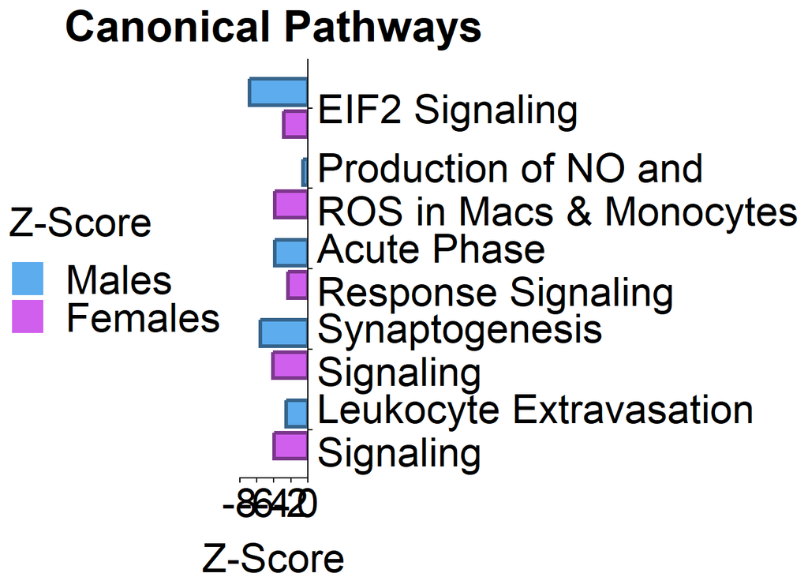

```r
# Using as.factor() to create a new col with the same pathways names, but adjusted with \n for the plot.
M.F$Pathway2 <- as.factor(c(
  "EIF2 Signaling",
  "Acute Phase \nResponse Signaling",
  "Production of NO and \nROS in Macs & Monocytes",
  "Leukocyte Extravasation \nSignaling",
  "Synaptogenesis \nSignaling",
  "EIF2 Signaling",
  "Acute Phase \nResponse Signaling",
  "Production of NO and \nROS in Macs & Monocytes",
  "Leukocyte Extravasation \nSignaling",
  "Synaptogenesis \nSignaling"))

# Create plot.
sex_plot <- M.F %>%
  ggplot(aes(x = reorder(Pathway2, Difference), y = Z_Score, fill = Sex, color = Sex)) +
  geom_col(position = position_dodge(0.8), size = 1.1, width = 0.65) +

  scale_fill_manual(labels = c("Females", "Males"), values = c("mediumorchid2", "steelblue2")) +
  scale_color_manual(values = c("mediumorchid4", "steelblue4"), guide = "none") +

  guides(fill = guide_legend(reverse=TRUE)) +

  scale_x_discrete(position = "top") +
  scale_y_continuous(expand = c(0, 0), limits = c(-8, 0)) +

  labs(title = "Canonical Pathways", x = "", y = "Z-Score", fill = "Z-Score") +

  theme_cowplot(12) +

  theme(
        axis.line = element_line(colour = "black"),

        plot.title = element_text(hjust = 0.5, face = "bold", size = 27),
        axis.title.y = element_blank(),
        axis.text.y = element_text(colour = "black", size = 25),
        axis.title.x = element_text(colour = "black", size = 25, vjust = -0.5),
        axis.text.x = element_text(colour = "black", size = 25),

        legend.position = "left",
        legend.title = element_text(size = 25),
        legend.text = element_text(size = 25),
        legend.key.size = unit(8, 'mm')) +

  coord_flip()
sex_plot
```

```r
ggsave(
  "canon_pathway_sex_06.07.2024.jpg",
  plot = last_plot(),
  path = plot.path,
  width = 15,
  height = 8,
  dpi = 1200)
```

# Analysis of cell differential data and cytokine data

Clean dataframe and subset specific columns.

```r
# Read in files.
Data <- read_excel("C:/Users/mnale/OneDrive - University of North Carolina at Chapel Hill/WSP Proteomics Project/data/DEMOGRAPHICS_FINAL.xlsx", sheet = "Smokescreen_Data_R")

# Remove all spaces, change all letters to lowercase, change '-' to '_'
Data <- clean_names(Data)

# Relabel the 'visit' classifications.
Data <- Data %>%
  mutate(timepoint =
           case_when(
             visit == "Screen" ~ "Pre",
             visit == "Post" ~ "Post_6hr",
             visit == "FU" ~ "Post_24hr"
           ))

# Rename the m1 and m2 col names.
Data <- Data %>%
  rename("percent_iNOS_sputum" = "percent_m1_sputum",
         "percent_CD301_sputum" = "percent_m2_sputum",
         "pmn_per_mg" = "sputum_pmn_cells_per_mg")

# Select the relevant cols.
Data <- Data %>%
  select(c(subject, sex, timepoint, sputum_percent_pmn, pmn_per_mg
, il_1b_sputum, il_6_sputum, il_8_sputum, tn_fa_sputum,
           percent_iNOS_sputum, percent_CD301_sputum, neutrophils_percentage, il_1b_serum, il_6_serum, il_8_serum,
           tn_fa_serum))

# Log2 transform all data except percentages.
cols <- c("pmn_per_mg", "il_1b_sputum", "il_6_sputum", "il_8_sputum", "tn_fa_sputum",
          "il_1b_serum", "il_6_serum", "il_8_serum",
           "tn_fa_serum")

# Make a copy of my Data df for log2 transformations
Data_Log2 <- data.frame(Data)

Data_Log2[cols] <- (log2(Data_Log2[cols]))
Data_Log2[cols] <- Data_Log2[cols] + 8 # Transform by +8 to keep the values all positive

# Some counts were zero and the log2 of 0 is undefined, so I am replacing the +/- Inf with NAs
Data_Log2[cols][sapply(Data_Log2[cols], is.infinite)] <- NA

# Remove Post_6hr time point
Data_Log2 <- Data_Log2 %>% filter(timepoint == "Pre" | timepoint == "Post_24hr")

head(Data_Log2)
```

```
##   subject    sex timepoint sputum_percent_pmn pmn_per_mg il_1b_sputum
## 1       1   Male       Pre              77.20   14.08937    11.549196
## 2       2   Male       Pre              48.09   17.32463    14.243672
## 3       3 Female       Pre              11.40   14.76951    11.280538
## 4       4   Male       Pre              16.07   14.39232    10.390327
## 5       5 Female       Pre              19.33   15.35438     7.891844
## 6       6 Female       Pre              22.60   15.15987    11.958086
##   il_6_sputum il_8_sputum tn_fa_sputum percent_iNOS_sputum percent_CD301_sputum
## 1    9.008596    17.03672     6.790136                  NA                   NA
## 2   12.141614    18.60927    10.581592                3.00                91.00
## 3    9.951668    16.63201     8.928231               23.96                29.17
## 4    9.256210    15.41172     5.352290                0.00                99.00
## 5    9.393608    14.68625     6.580913               16.00                83.00
## 6   10.766483    16.08640     8.014095               77.00                19.00
##   neutrophils_percentage il_1b_serum il_6_serum il_8_serum tn_fa_serum
## 1                     54    6.596307   9.408810   14.15177   11.004736
## 2                     52    3.302437   6.629529   12.17329    9.895564
## 3                     51    8.040854   8.367635   11.99835    9.955868
## 4                     61    3.951067   8.298068   11.96726    9.855501
## 5                     56    4.211018   5.877216   11.74381   10.139980
## 6                     58          NA   7.479654   12.18991    9.852217
```

## 2-way ANOVAs

Run 2-way anovas for each cytokine, using timepoint and sex as independent variables. Should any p<0.06, I will run a Tukey Post-Hoc test. In this analysis, I will exclude rows that contain NAs.

```r
# I will make an object that will run function x across each column beginning at column 4.
anova.results <- lapply(colnames(Data_Log2)[4:ncol(Data_Log2)], function(x) as.formula(paste0(x, " ~ timepoint * sex")))

# Now, we use the lapply() to incorporate our function into the aov() and generate the summary stats for each column variable.
# NOTE: NAs will be dropped automatically by aov()
res <- lapply(anova.results, function(x) summary(aov(x, data = Data_Log2)))
names(res) <- format(anova.results)
res

# Based on out results, we can run a Tukey's Post-Hoc across The following variables:
# sputum_percent_pmn, il_1b_sputum ,il_6_sputum , il_8_sputum , neutrophils_percentage, tn_fa_sputum
posthoc.results.1 <- lapply(colnames(Data_Log2)[c(4:9)], function(x) as.formula(paste0(x, " ~ timepoint * sex")))
res.posthoc.1 <-lapply(posthoc.results.1, function(x) TukeyHSD(aov(x, data = Data_Log2)))
names(res.posthoc.1) <- format(posthoc.results.1)
res.posthoc.1
```

[output not shown]

Generate summary statistics across each variable.

```r
# Make a longer format of data.
Data_Log2_Long <- Data_Log2 %>%
  pivot_longer(
    cols = sputum_percent_pmn:tn_fa_serum,
    names_to = "variable",
    values_to = "value"
  )

Sum_Stats_Log2 <- Data_Log2_Long %>%
  group_by(variable, timepoint, sex) %>%
  summarise(
    mean = mean(value, na.rm = TRUE),
    sd = sd(value, na.rm = TRUE),
    n = sum(!is.na(value)),
    se = sd / sqrt(n),
    .groups = 'drop'
  )

head (Sum_Stats_Log2)
```

```
## # A tibble: 6 × 7
##   variable     timepoint sex     mean    sd     n    se
##   <chr>        <chr>     <chr>  <dbl> <dbl> <int> <dbl>
## 1 il_1b_serum  Post_24hr Female  3.68  1.06    13 0.293
## 2 il_1b_serum  Post_24hr Male    3.20  1.49    10 0.472
## 3 il_1b_serum  Pre       Female  3.76  1.95    13 0.540
## 4 il_1b_serum  Pre       Male    4.69  1.26    12 0.364
## 5 il_1b_sputum Post_24hr Female 10.5   1.76    23 0.368
## 6 il_1b_sputum Post_24hr Male   11.8   1.27    17 0.307
```

Clean up the final df using pivot_wider() and renaming the cols.

```r
Sum_Stats_Log2_Wide <- Sum_Stats_Log2 %>%
 pivot_wider(names_from = timepoint, values_from = c(mean, sd, n, se))

oldnames = c("variable", "sex", "mean_Post_24hr",  "mean_Pre", "sd_Post_24hr",
             "sd_Pre", "n_Post_24hr",  "n_Pre", "se_Post_24hr",  "se_Pre")

newnames = c("Variable", "Sex", "Post_24hr_Mean",  "Pre_Mean", "Post_24hr_SD",
             "Pre_SD", "Post_24hr_N",  "Pre_N", "Post_24hr_SE",  "Pre_SE")

Sum_Stats_Log2_Wide <- Sum_Stats_Log2_Wide %>% rename_at(vars(oldnames), ~ newnames)
# Here is the final df
Sum_Stats_FINAL <- Sum_Stats_Log2_Wide %>%
  select(Variable, Sex, Pre_Mean, Pre_SD, Pre_N, Pre_SE,
         Post_24hr_Mean, Post_24hr_SD, Post_24hr_N, Post_24hr_SE)

# Save dataframe
write.xlsx(Sum_Stats_FINAL,"../output_FINAL/CellDiff_Cytokine_Sum_Stats_v2_02.13.2024.xlsx")
```

## Plots of cell differentials and cytokine measures

Sputum Percent PMN

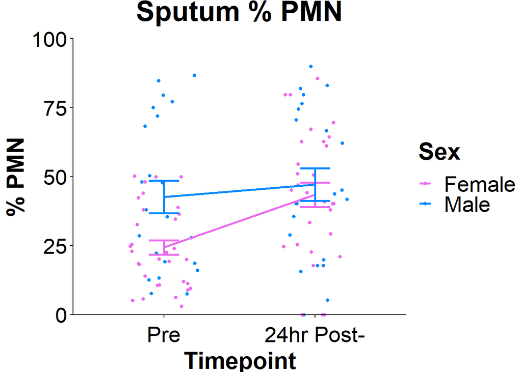

```r
# Set a path for saving plots
plot.path <- "C:/Users/mnale/OneDrive - University of North Carolina at Chapel Hill/WSP Proteomics Project/output_FINAL/Plots_FINAL"

PMN_1 <- Sum_Stats_FINAL %>%
  filter(Variable == "sputum_percent_pmn") %>%
  select(Variable, Sex, Pre_Mean, Post_24hr_Mean) %>%
  pivot_longer(cols = c(Pre_Mean, Post_24hr_Mean),
               names_to = "Timepoint_Mean",
               values_to = "Mean") %>%
  mutate(Timepoint =
           case_when(Timepoint_Mean == "Pre_Mean" ~ "Pre",
                     Timepoint_Mean == "Post_24hr_Mean" ~ "Post_24hr")) %>%
  select(-Timepoint_Mean)

PMN_2 <- Sum_Stats_FINAL %>%
  filter(Variable == "sputum_percent_pmn") %>%
  select(Variable, Sex, Pre_SE, Post_24hr_SE) %>%
  pivot_longer(cols = c(Pre_SE, Post_24hr_SE),
               names_to = "Timepoint_SE",
               values_to = "SE")  %>%
  mutate(Timepoint =
           case_when(Timepoint_SE == "Pre_SE" ~ "Pre",
                     Timepoint_SE == "Post_24hr_SE" ~ "Post_24hr")) %>%
  select(-Timepoint_SE)

PMN_df <- merge(PMN_1, PMN_2, by = c("Variable", "Sex", "Timepoint"))

###### Generate Plot

new_labels <- c("Pre", "24hr Post-") # New labels for the x-axis ticks

PMN_Plot <- ggplot() +

   geom_point(Data_Log2,
     mapping = aes(x = factor(timepoint, levels = c("Pre", "Post_24hr")),
                   y = sputum_percent_pmn,
                   colour = sex),
                   size = 1.3,
                   position = position_jitterdodge(dodge.width = 0.1)) +

   geom_line(PMN_df, mapping = aes(x = factor(Timepoint,
                   levels = c("Pre", "Post_24hr")),
                   y = Mean,
                   group = Sex,
                   color = Sex),
                      size = 1) +

  geom_errorbar(PMN_df, mapping = aes(x = factor(Timepoint,
                   levels = c("Pre", "Post_24hr")),
                   y = Mean,
                   colour = Sex,
                   ymin = Mean - SE, ymax = Mean + SE),
                     width = 0.2,
                     linewidth = 0.9) +

  scale_colour_manual(values = c("#ED68ED", "#0089FF")) +
    xlab("Timepoint") +
    ylab("% PMN") +
    ggtitle("Sputum % PMN") +
  scale_y_continuous(expand = c(0, 0), limits = c(0, 100)) +

  scale_x_discrete(labels = new_labels) +

  guides(color = guide_legend(title = "Sex")) +

  coord_cartesian(clip = "off") +

  theme_cowplot(12) +

  theme(
    plot.title = element_text(hjust = 0.5, vjust = 2, size = 27, face = "bold"),
    axis.title = element_text(size = 23, face = "bold"),
    legend.title = element_text(size = 23, face = "bold"),

    axis.text = element_text(size = 21),
    axis.text.x = element_text(vjust = -0.3),
    axis.title.x = element_text(vjust = -0.6),
    legend.text = element_text(size = 21),

    axis.line = element_line(colour = "black"),
    panel.grid.minor = element_blank(),
    panel.border = element_blank(),
    panel.background = element_blank())
PMN_Plot
```

```r
ggsave(
  "Sputum Percent PMN_02.13.2024.png",
  plot = last_plot(),
  path = plot.path,
  width = 8,
  height = 6,
  dpi = 1200)
```

IL-8

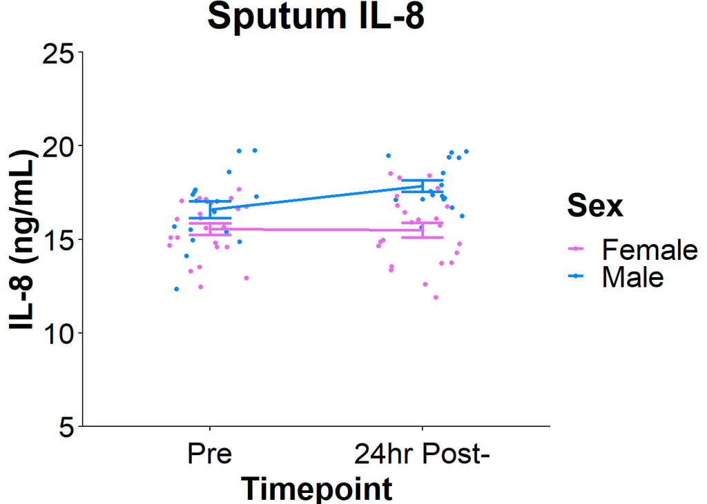

```r
# Reformat the df
IL8_1 <- Sum_Stats_FINAL %>%
  filter(Variable == "il_8_sputum") %>%
  select(Variable, Sex, Pre_Mean, Post_24hr_Mean) %>%
  pivot_longer(cols = c(Pre_Mean, Post_24hr_Mean),
               names_to = "Timepoint_Mean",
               values_to = "Mean") %>%
  mutate(Timepoint =
           case_when(Timepoint_Mean == "Pre_Mean" ~ "Pre",
                     Timepoint_Mean == "Post_24hr_Mean" ~ "Post_24hr")) %>%
  select(-Timepoint_Mean)

IL8_2 <- Sum_Stats_FINAL %>%
  filter(Variable == "il_8_sputum") %>%
  select(Variable, Sex, Pre_SE, Post_24hr_SE) %>%
  pivot_longer(cols = c(Pre_SE, Post_24hr_SE),
               names_to = "Timepoint_SE",
               values_to = "SE")  %>%
  mutate(Timepoint =
           case_when(Timepoint_SE == "Pre_SE" ~ "Pre",
                     Timepoint_SE == "Post_24hr_SE" ~ "Post_24hr")) %>%
  select(-Timepoint_SE)

IL8_df <- merge(IL8_1, IL8_2, by = c("Variable", "Sex", "Timepoint"))

###### Genereate Plot
new_labels <- c("Pre", "24hr Post-") # New labels for the x-axis ticks

IL8_Plot <- ggplot() +
    geom_point(Data_Log2,
     mapping = aes(x = factor(timepoint, levels = c("Pre", "Post_24hr")),
                   y = il_8_sputum,
                   colour = sex),
                   position = position_jitterdodge(dodge.width = 0.1),
                   size = 1.3) +

  geom_line(IL8_df, mapping = aes(x = factor(Timepoint,
                   levels = c("Pre", "Post_24hr")),
                   y = Mean,
                   group = Sex,
                   color = Sex),
                      size = 1) +

  geom_errorbar(IL8_df, mapping = aes(x = factor(Timepoint,
                   levels = c("Pre", "Post_24hr")),
                   y = Mean,
                   colour = Sex,
                   ymin = Mean - SE, ymax = Mean + SE),
                     width = 0.2,
                     linewidth = 0.9) +

  scale_colour_manual(values = c("#ED68ED", "#0089FF")) +
    xlab("Timepoint") +
    ylab("IL-8 (ng/mL)") +
    ggtitle("Sputum IL-8") +
  scale_y_continuous(expand = c(0, 0), limits = c(5, 25)) +

  scale_x_discrete(labels = new_labels) +

  guides(color = guide_legend(title = "Sex")) +

  theme_cowplot(12) +

  theme(
    plot.title = element_text(hjust = 0.5, vjust = 2, size = 27, face = "bold"),
    axis.title = element_text(size = 23, face = "bold"),
    legend.title = element_text(size = 23, face = "bold"),

    axis.text = element_text(size = 21),
    axis.text.x = element_text(vjust = -0.3),
    axis.title.x = element_text(vjust = -0.6),
    legend.text = element_text(size = 21),

    axis.line = element_line(colour = "black"),
    panel.grid.minor = element_blank(),
    panel.border = element_blank(),
    panel.background = element_blank())
IL8_Plot
```

```r
ggsave(
  "IL8 Sputum_02.13.2024.png",
  plot = last_plot(),
  path = plot.path,
  width = 8,
  height = 6,
  dpi = 1200)
```

iNOS

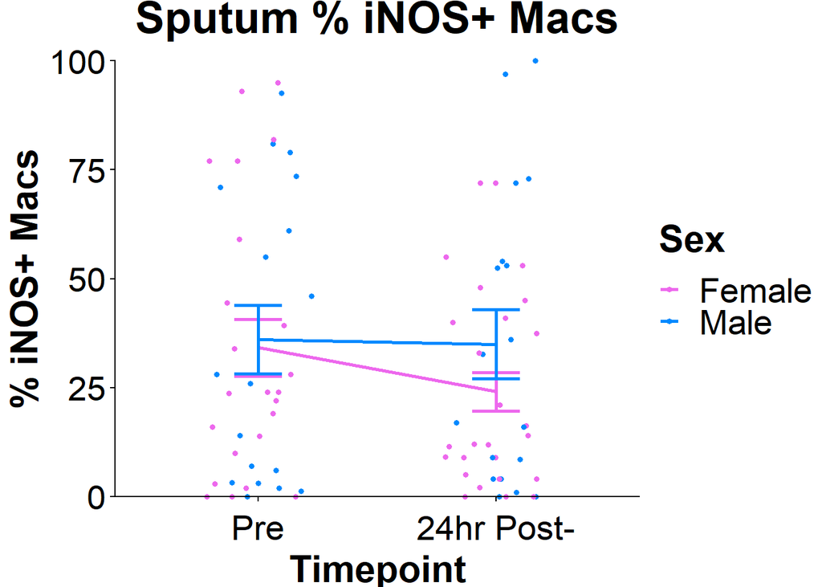

```r
iNOS_1 <- Sum_Stats_FINAL %>%
  filter(Variable == "percent_iNOS_sputum") %>%
  select(Variable, Sex, Pre_Mean, Post_24hr_Mean) %>%
  pivot_longer(cols = c(Pre_Mean, Post_24hr_Mean),
               names_to = "Timepoint_Mean",
               values_to = "Mean") %>%
  mutate(Timepoint =
           case_when(Timepoint_Mean == "Pre_Mean" ~ "Pre",

                     Timepoint_Mean == "Post_24hr_Mean" ~ "Post_24hr")) %>%
  select(-Timepoint_Mean)

iNOS_2 <- Sum_Stats_FINAL %>%
  filter(Variable == "percent_iNOS_sputum") %>%
  select(Variable, Sex, Pre_SE, Post_24hr_SE) %>%
  pivot_longer(cols = c(Pre_SE, Post_24hr_SE),
               names_to = "Timepoint_SE",
               values_to = "SE")  %>%
  mutate(Timepoint =
           case_when(Timepoint_SE == "Pre_SE" ~ "Pre",

                     Timepoint_SE == "Post_24hr_SE" ~ "Post_24hr")) %>%
  select(-Timepoint_SE)

iNOS_df <- merge(iNOS_1, iNOS_2, by = c("Variable", "Sex", "Timepoint"))

###### Generate Plot
new_labels <- c("Pre", "24hr Post-") # New labels for the x-axis ticks

iNOS_Plot <- ggplot() +
    geom_point(Data_Log2,
     mapping = aes(x = factor(timepoint, levels = c("Pre", "Post_24hr")),
                   y = percent_iNOS_sputum,
                   colour = sex),
                   position = position_jitterdodge(dodge.width = 0.1),
                   size = 1.3) +

  geom_line(iNOS_df, mapping = aes(x = factor(Timepoint,
                   levels = c("Pre", "Post_24hr")),
                   y = Mean,
                   group = Sex,
                   color = Sex),
                      size = 1) +

  geom_errorbar(iNOS_df, mapping = aes(x = factor(Timepoint,
                   levels = c("Pre", "Post_24hr")),
                   y = Mean,
                   colour = Sex,
                   ymin = Mean - SE, ymax = Mean + SE),
                     width = 0.2,
                     linewidth = 0.9) +

  scale_colour_manual(values = c("#ED68ED", "#0089FF")) +
    xlab("Timepoint") +
    ylab("% iNOS+ Macs") +
    ggtitle("Sputum % iNOS+ Macs") +
  scale_y_continuous(expand = c(0, 0), limits = c(0, 100)) +

  scale_x_discrete(labels = new_labels) +

  guides(color = guide_legend(title = "Sex")) +

  theme_cowplot(12) +

  coord_cartesian(clip = "off") +

  theme(
    plot.title = element_text(hjust = 0.5, vjust = 2, size = 27, face = "bold"),
    axis.title = element_text(size = 23, face = "bold"),
    legend.title = element_text(size = 23, face = "bold"),

    axis.text = element_text(size = 21),
    axis.text.x = element_text(vjust = -0.3),
    axis.title.x = element_text(vjust = -0.6),
    legend.text = element_text(size = 21),

    axis.line = element_line(colour = "black"),
    panel.grid.minor = element_blank(),
    panel.border = element_blank(),
    panel.background = element_blank())
iNOS_Plot
```

```r
ggsave(
  "iNOS Sputum_02.13.2024.png",
  plot = last_plot(),
  path = plot.path,
  width = 8,
  height = 6,
  dpi = 1200)
```